# Final HW 4

Janna M

9/25/2021

```r
library(devtools)
library(tidyverse)
library(patchwork)
library(dplyr)
library(tidycovid19)
library(BBmisc)
library(scales)
library(collapse)
install_github("joachim-gassen/tidycovid19")
```

[output not shown]

[output not shown]

[output not shown]

[output not shown]

[output not shown]

[output not shown]

[output not shown]

```r
merged <- download_merged_data(cached = TRUE)
```

[output not shown]

```r
download_jhu_csse_covid19_data()
```

```
## Start downloading JHU CSSE Covid-19 data
```

```
## Done downloading JHU CSSE data
```

```
##
## Data Info:
```

[output not shown]

```
## Systems Science and Engineering (JHU CSSE) relies upon publicly
```

```
## available data from multiple sources that do not always agree. It is
```

```
## updated daily. The data comes in three data frames that you can select
```

```
## by the 'type' parameter. The 'country' data frame contains the global
```

```
## country-level data reported by JHU CSSE by aggregating over the
```

```
## regional data for countries that have regional data available. The
```

```
## 'country_region' data frame provides regional data for the countries
```

```
## that have regional data available (mosty Australia, Canada and China).
```

```
## The 'us_county' data frame reports the data for the U.S. at the county
```

```
## level. The column 'timestamp' reports the time the data was downloaded
```

```
## from its authoritative source.
```

```
## For further information refer to:
```

```
## https://github.com/CSSEGISandData/COVID-19.
```

```
## # A tibble: 116,280 x 7
##    country     iso3c date       confirmed deaths recovered timestamp
##    <chr>       <chr> <date>         <dbl>  <dbl>     <dbl> <dttm>
##  1 Afghanistan AFG   2020-01-22         0      0         0 2021-09-25 13:52:56
##  2 Afghanistan AFG   2020-01-23         0      0         0 2021-09-25 13:52:56
##  3 Afghanistan AFG   2020-01-24         0      0         0 2021-09-25 13:52:56
##  4 Afghanistan AFG   2020-01-25         0      0         0 2021-09-25 13:52:56
##  5 Afghanistan AFG   2020-01-26         0      0         0 2021-09-25 13:52:56
##  6 Afghanistan AFG   2020-01-27         0      0         0 2021-09-25 13:52:56
##  7 Afghanistan AFG   2020-01-28         0      0         0 2021-09-25 13:52:56
##  8 Afghanistan AFG   2020-01-29         0      0         0 2021-09-25 13:52:56
##  9 Afghanistan AFG   2020-01-30         0      0         0 2021-09-25 13:52:56
## 10 Afghanistan AFG   2020-01-31         0      0         0 2021-09-25 13:52:56
## # ... with 116,270 more rows
```

```r
download_wbank_data()
```

```
## Start downloading World Bank data
```

```
## Done downloading World Bank data
```

```
##
## Data Info:
```

[output not shown]

```
## Bank. The regional and income level classifications are also provided
```

```
## by the World Bank. 'life_expectancy' is measured in years at birth and
```

```
## 'gdp_capita' is measured in 2010 US-$. The original World Bank data
```

```
## items are (in the order how they are represented in the data frame)
```

```
## 'SP.POP.TOTL', 'AG.LND.TOTL.K2', 'EN.POP.DNST', 'EN.URB.LCTY',
```

```
## 'SP.DYN.LE00.IN', 'NY.GDP.PCAP.KD'. When you set the parameter
```

```
## 'var_def' tot 'TRUE'. the data comes in a list containing two data
```

```
## frames. The first contains the actual data, the second contains
```

```
## variable definitions. The column 'timestamp' reports the time the data
```

```
## was downloaded from its authoritative source.
```

```
## For further information refer to: https://data.worldbank.org.
```

```
## # A tibble: 217 x 11
##    iso3c country              region income population land_area_skm pop_density
##    <chr> <chr>                <chr>  <chr>       <dbl>         <dbl>       <dbl>
##  1 ABW   Aruba                "Lati~ High ~     106766           180       593.
##  2 AFG   Afghanistan          "Sout~ Low i~   38928341        652860        59.6
##  3 AGO   Angola               "Sub-~ Lower~   32866268       1246700        26.4
##  4 ALB   Albania              "Euro~ Upper~    2837743         27400       104.
##  5 AND   Andorra              "Euro~ High ~      77265           470       164.
##  6 ARE   United Arab Emirates "Midd~ High ~    9890400         71020       139.
##  7 ARG   Argentina            "Lati~ Upper~   45376763       2736690        16.6
##  8 ARM   Armenia              "Euro~ Upper~    2963234         28470       104.
##  9 ASM   American Samoa       "East~ Upper~      55197           200       276.
## 10 ATG   Antigua and Barbuda  "Lati~ High ~      97928           440       223.
## # ... with 207 more rows, and 4 more variables: pop_largest_city <dbl>,
## #   life_expectancy <dbl>, gdp_capita <dbl>, timestamp <dttm>
```

```r
merged <- download_merged_data(cached = TRUE)
```

[output not shown]

```r
merged <- merged %>% group_by(country, iso3c) %>%
  arrange(country, iso3c, date) %>%
  ## code to drop recovered
  ##select(-recovered) %>%
  ##code to replace NAs with zeros
  mutate(
    confirmed = ifelse(is.na(confirmed), 0, confirmed),
    deaths = ifelse(is.na(deaths), 0, deaths),
    recovered = ifelse(is.na(recovered),0, recovered)) %>%
  mutate(
    daily_confirmed = confirmed - lag(confirmed, n = 1),
    daily_deaths = deaths - lag(deaths, n = 1),
    daily_recovered = recovered - lag(recovered, n = 1)) %>%
  mutate(
    daily_confirmed = replace_na(daily_confirmed, 0),
    daily_deaths = replace_na(daily_deaths, 0),
    daily_recovered = replace_na(daily_recovered,0)) %>%
  ungroup() %>%
  arrange(country, iso3c, date)

add_world1 <- merged %>% group_by(date) %>%
  arrange(date) %>%
  summarize(
    country = "World",
    iso3c = NA,
    confirmed = sum(confirmed, na.rm = TRUE),
    deaths = sum(deaths, na.rm = TRUE),
    recovered = sum(recovered, na.rm = TRUE),
    timestamp = fmode(timestamp)) %>%
  mutate(
    daily_confirmed = confirmed - lag(confirmed, n = 1),
    daily_deaths = deaths - lag(deaths, n = 1),
    daily_recovered = recovered - lag(recovered, n = 1)) %>%
  mutate(
    daily_confirmed = replace_na(daily_confirmed, 0),
    daily_deaths = replace_na(daily_deaths, 0),
    daily_recovered = replace_na(daily_recovered,0)) %>%
  ungroup() %>%
  arrange(country, iso3c, date)

add_world2 <- merged %>% group_by(country, iso3c) %>%
  summarize(
    population = fmode(population),
    land_area_skm = fmode(land_area_skm),
    timestamp = fmode(timestamp)) %>%
  ungroup() %>%
  summarize(
    country = "World", iso3c = NA,
    population = sum(population, na.rm = TRUE),
    land_area_skm = sum(land_area_skm, na.rm = TRUE)) %>%
  mutate(pop_density = population / land_area_skm)
add_world <- left_join(add_world1, add_world2, by = c("country", "iso3c"))
merged <- bind_rows(merged, add_world)

cv_data <- pivot_longer(merged,
    cols=c("confirmed", "deaths","recovered",
    "daily_confirmed", "daily_deaths","daily_recovered"),
    names_to = "variable", values_to = "cases"
  ) %>%
  arrange(country, variable, date) %>%
  rename(area = land_area_skm, density = pop_density) %>%
  mutate(rate = cases / population * 10^6) %>%
  ## code to omit data after 2021-07-01
  filter(date < "2021-07-01")

rm(list=c("merged", "add_world", "add_world1", "add_world2"))
```

```r
cv_summary <- function(d, country_list = "World",
  plot = TRUE, facet = "country",
  status = c("confirmed", "deaths")){
  # based on `wes_palettes()` color schemes GrandBudapest1, IsleofDogs1,
  # IsleofDogs2 from the {wesanderson} package
  my_palette <- c("#5B1A18", "#FD6467", "#F1BB7B",
    "#D67236", "#0F0D0E", "#9986A5", "#79402E",
    "#CCBA72", "#D9D0D3", "#8D8680", "#EAD3BF",
    "#AA9486", "#B6854D", "#39312F", "#1C1718")

  if (facet == "country"){
    fill <- "variable"
    n <- length(unique(d$variable)) / 2
    # need only half of unique # of variables (3)
  }

  if (facet == "variable"){
    fill <- "country"
    n <- length(country_list)
    # need number of countries
  }

  if ("All" %in% country_list) {
    country_list <- unique(d$country)
    country_list <- setdiff(country_list, "World")
  }

  if ("World" %in% country_list) {
    d <- d %>% filter(country %in% country_list)

    totals <- d %>% group_by(variable) %>%
      summarize(
        country = "World",
        cases = max(cases),
        population = max(population),
        area = max(area),
        density = max(density),
        rate = max(rate, na.rm = TRUE),
        on = max(date)
      ) %>%
      select(country, variable, cases, population, area, density, rate, on) %>%
      arrange(variable) %>%
      ungroup()
  }

  if ("World" %nin% country_list) {
    d <- d %>% filter(country %in% country_list)
    totals <- d %>% group_by(country, variable) %>%
      summarize(
        cases = max(cases),
        population = max(population),
        area = max(area),
        density = max(density),
        rate = max(rate, na.rm = TRUE),
        on = max(date),
        gdp_capita = fmode(gdp_capita),
        income = fmode(income),
        life_expectancy = fmode(life_expectancy),
        max_sd = max(soc_dist),
        max_mr = max(mov_rest)
      ) %>%
      select(country, variable, cases, population, area, density, rate,
        gdp_capita, income, life_expectancy, max_sd, max_mr, on) %>%
      arrange(country, variable) %>%
      ungroup()
  }

  if (plot == TRUE){
    cc <- filter(d, variable %in% status)
    cum_cases_plot <- ggplot(
      data = cc,
        # use the tidy evaluation pronoun .data to slice the chosen fill
        # variable from the data frame
        aes(x = date, y = cases + 1, color = .data[[fill]],
          fill = .data[[fill]])) +
      geom_point(size = 0.5) +
      geom_line() +
      # use the tidy evaluation pronoun .data to slice the chosen facet_wrap
      # variable from the data frame
      facet_wrap(~ .data[[facet]], ncol = 4, scales = "free_y") +
      xlab("Date") + ylab("Log Cumulative Cases") +
      scale_y_log10(
        breaks = trans_breaks("log10", function(x) 10^x),
        labels = trans_format("log10", math_format(10^.x))) +
      scale_color_manual(aesthetics = c("color", "fill"),
        name = NULL, values = my_palette)

    dc <- filter(d, variable %in% paste0("daily_", status))
    daily_cases_plot <- ggplot(
      data = dc,
        aes(x = date, y = cases, color = .data[[fill]],
          fill = .data[[fill]])) +
      geom_point(size = 0.5) +
      geom_line() +
      facet_wrap(~ .data[[facet]], ncol = 4, scales = "free_y") +
      xlab("Date") + ylab("Daily Cases") +
      scale_color_manual(aesthetics = c("color", "fill"),
        name = NULL, values = my_palette)
  }

  if (plot == TRUE) {
    return(list(totals = totals,
      cum_cases_plot = cum_cases_plot,
      daily_cases_plot = daily_cases_plot)
    )
  } else {
    return(list(totals = totals))
  }
}
```

Challange 1

Use the dataset and function generated above to plot global data on confirmed coronavirus infections, deaths, and recoveries.

HINT: To do this, you will want to look at the various arguments of the function and its defaults, as well as at the structure of the data object returned by the function.

```r
#Global Confirmed cases
cv_summary(cv_data, status = c("confirmed", "deaths", "recovered"))
```

```
## $totals
## # A tibble: 6 x 8
##   country variable            cases population       area density   rate on
##   <chr>   <chr>               <dbl>      <dbl>      <dbl>   <dbl>  <dbl> <date>
## 1 World   confirmed       182152054 7686696685 129320532.    59.4 2.37e4 2021-06-30
## 2 World   daily_confirmed   1500277 7686696685 129320532.    59.4 1.95e2 2021-06-30
## 3 World   daily_deaths        17967 7686696685 129320532.    59.4 2.34e0 2021-06-30
## 4 World   daily_recovered   1504377 7686696685 129320532.    59.4 1.96e2 2021-06-30
## 5 World   deaths            3948788 7686696685 129320532.    59.4 5.14e2 2021-06-30
## 6 World   recovered       119474580 7686696685 129320532.    59.4 1.55e4 2021-06-30
##
## $cum_cases_plot
```

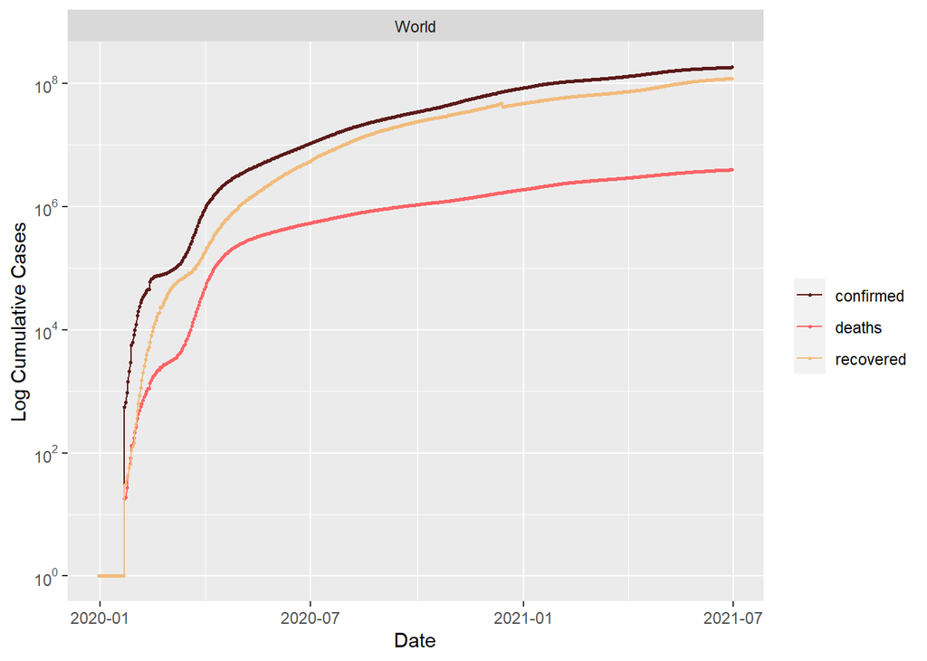

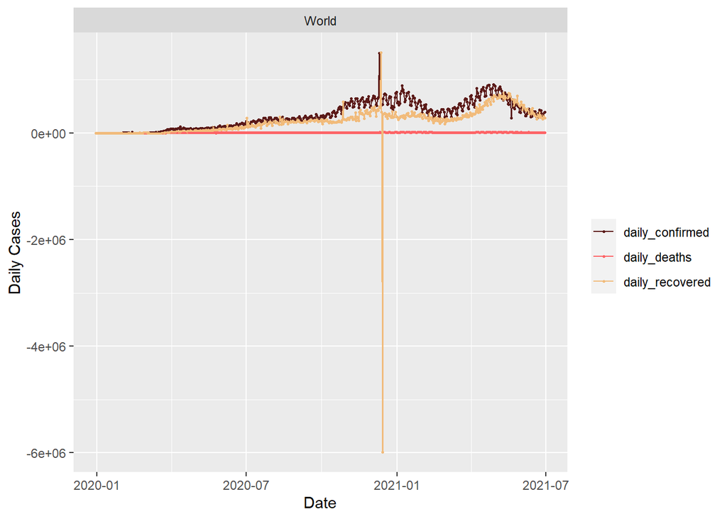

```r
cv_summary(cv_data, status = c("confirmed", "deaths", "recovered"),
country_list = c("United States", "United Kingdom", "Germany", "South Africa", "China", "Russia", "Iran","India"))
```

```
## $totals
## # A tibble: 48 x 13
##    country variable   cases population   area density    rate gdp_capita income
##    <chr>   <chr>      <dbl>      <dbl>  <dbl>   <dbl>   <dbl>      <dbl> <chr>
##  1 China   confirmed 1.04e5 1402112000 9.42e6    149. 7.40e+1      8405. Upper ~
##  2 China   daily_co~ 1.51e4 1402112000 9.42e6    149. 1.08e+1      8405. Upper ~
##  3 China   daily_de~ 1.29e3 1402112000 9.42e6    149. 9.20e-1      8405. Upper ~
##  4 China   daily_re~ 4.00e3 1402112000 9.42e6    149. 2.85e+0      8405. Upper ~
##  5 China   deaths    4.85e3 1402112000 9.42e6    149. 3.46e+0      8405. Upper ~
##  6 China   recovered 9.84e4 1402112000 9.42e6    149. 7.02e+1      8405. Upper ~
##  7 Germany confirmed 3.74e6   83240525 3.49e5    238. 4.49e+4     45065. High i~
##  8 Germany daily_co~ 4.90e4   83240525 3.49e5    238. 5.89e+2     45065. High i~
##  9 Germany daily_de~ 1.73e3   83240525 3.49e5    238. 2.08e+1     45065. High i~
## 10 Germany daily_re~ 4.45e4   83240525 3.49e5    238. 5.35e+2     45065. High i~
## # ... with 38 more rows, and 4 more variables: life_expectancy <dbl>,
## #   max_sd <dbl>, max_mr <dbl>, on <date>
##
## $cum_cases_plot
```

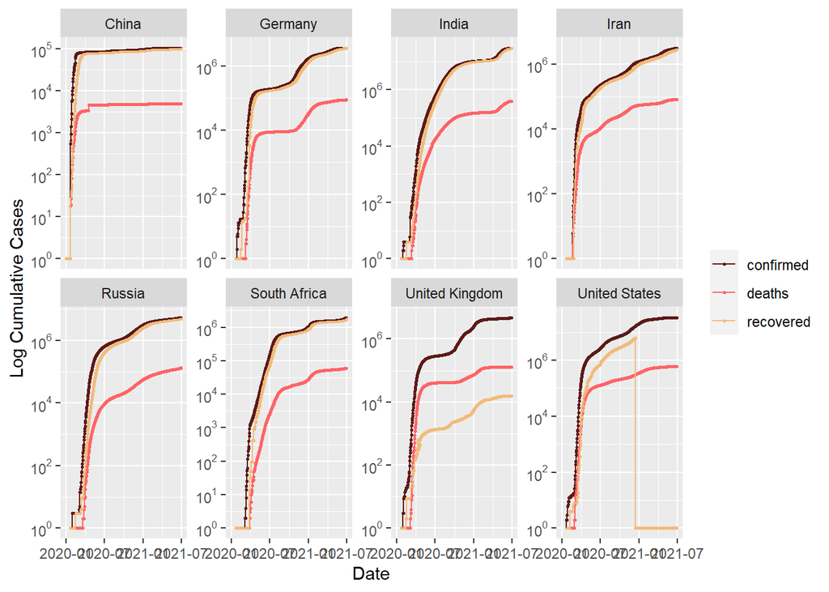

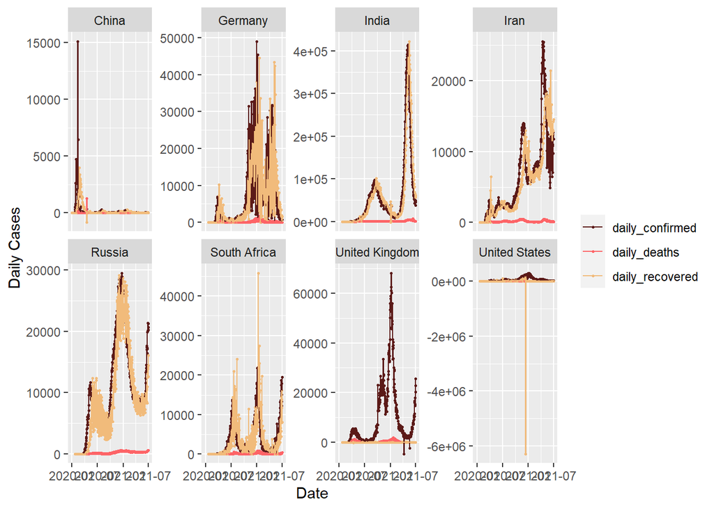

CHALLENGE 3: Use the dataset and function generated above to return summary data for ALL countries in the dataset, and then filter this returned dataset to only those countries with populations of over one million, storing this dataset as a tibble d. How many countries does this tibble include?

```r
cv_summary <- function(d, country_list = "World",
plot = TRUE, facet = "country",
status = c("confirmed", "deaths")){
# based on `wes_palettes()` color schemes GrandBudapest1, IsleofDogs1,
# IsleofDogs2 from the {wesanderson} package
my_palette <- c("#5B1A18", "#FD6467", "#F1BB7B",
"#D67236", "#0F0D0E", "#9986A5", "#79402E",
"#CCBA72", "#D9D0D3", "#8D8680", "#EAD3BF",
"#AA9486", "#B6854D", "#39312F", "#1C1718")

if (facet == "country"){
fill <- "variable"
n <- length(unique(d$variable)) / 2
# need only half of unique # of variables (3)
}

if (facet == "variable"){
fill <- "country"
n <- length(country_list)
# need number of countries
}

if ("All" %in% country_list) {
country_list <- unique(d$country)
country_list <- setdiff(country_list, "World")
}

if ("World" %in% country_list) {
d <- d %>% filter(country %in% country_list)

totals <- d %>% group_by(variable) %>%
summarize(
country = "World",
cases = max(cases),
population = max(population),
area = max(area),
density = max(density),
rate = max(rate, na.rm = TRUE),
on = max(date)
) %>%
select(country, variable, cases, population, area, density, rate, on) %>%
arrange(variable) %>%
ungroup()
}

if ("World" %nin% country_list) {
d <- d %>% filter(country %in% country_list)
totals <- d %>% group_by(country, variable) %>%
summarize(
cases = max(cases),
population = max(population),
area = max(area),
density = max(density),
rate = max(rate, na.rm = TRUE),
on = max(date),
gdp_capita = fmode(gdp_capita),
income = fmode(income),
life_expectancy = fmode(life_expectancy),
max_sd = max(soc_dist),
max_mr = max(mov_rest)
) %>%
select(country, variable, cases, population, area, density, rate,
gdp_capita, income, life_expectancy, max_sd, max_mr, on) %>%
arrange(country, variable) %>%
ungroup() %>%
filter(population > 1000000)
}

if (plot == TRUE){
cc <- filter(d, variable %in% status)
cum_cases_plot <- ggplot(
data = cc,
# use the tidy evaluation pronoun .data to slice the chosen fill
# variable from the data frame
aes(x = date, y = cases + 1, color = .data[[fill]],
fill = .data[[fill]])) +
geom_point(size = 0.5) +
geom_line() +
# use the tidy evaluation pronoun .data to slice the chosen facet_wrap
# variable from the data frame
facet_wrap(~ .data[[facet]], ncol = 4, scales = "free_y") +
xlab("Date") + ylab("Log Cumulative Cases") +
scale_y_log10(
breaks = trans_breaks("log10", function(x) 10^x),
labels = trans_format("log10", math_format(10^.x))) +
scale_color_manual(aesthetics = c("color", "fill"),
name = NULL, values = my_palette)

dc <- filter(d, variable %in% paste0("daily_", status))
daily_cases_plot <- ggplot(
data = dc,
aes(x = date, y = cases, color = .data[[fill]],
fill = .data[[fill]])) +
geom_point(size = 0.5) +
geom_line() +
facet_wrap(~ .data[[facet]], ncol = 4, scales = "free_y") +
xlab("Date") + ylab("Daily Cases") +
scale_color_manual(aesthetics = c("color", "fill"),
name = NULL, values = my_palette)
}

if (plot == TRUE) {
return(list(totals = totals,
cum_cases_plot = cum_cases_plot,
daily_cases_plot = daily_cases_plot)
)
} else {
return(totals)
}
}
```

```r
#creating a vector of all countries
all_countries <- c(unique(cv_data$country))
all_countries <- all_countries[all_countries != "World"]
d <- cv_summary(cv_data, plot = FALSE, country_list = all_countries)
```

[output not shown]

[output cut: 124 more lines]

[output not shown]

```r
head(d)
```

```
## # A tibble: 6 x 13
##   country  variable    cases population   area density   rate gdp_capita income
##   <chr>    <chr>       <dbl>      <dbl>  <dbl>   <dbl>  <dbl>      <dbl> <chr>
## 1 Afghani~ confirmed  118659   38928341 652860    59.6 3.05e3       549. Low in~
## 2 Afghani~ daily_con~   3243   38928341 652860    59.6 8.33e1       549. Low in~
## 3 Afghani~ daily_dea~    159   38928341 652860    59.6 4.08e0       549. Low in~
## 4 Afghani~ daily_rec~   1930   38928341 652860    59.6 4.96e1       549. Low in~
## 5 Afghani~ deaths       4871   38928341 652860    59.6 1.25e2       549. Low in~
## 6 Afghani~ recovered   71012   38928341 652860    59.6 1.82e3       549. Low in~
## # ... with 4 more variables: life_expectancy <dbl>, max_sd <dbl>, max_mr <dbl>,
## #   on <date>
```

The tibble includes 155 countries

CHALLENGE 4: Filter d to generate two additional tibbles, overall and daily that include only data on the variables “confirmed” and “daily_confirmed” cases, respectively. Depending on the dataset, the case and rate variables either reflect the overall (i.e., across the pandemic) or maximum daily number of cases and number of cases recorded per million people in the population.

Which 5 countries have experienced the highest overall rate of confirmed cases? Which 5 countries have experienced the highest single-day rate of confirmed cases? Which 5 countries have experienced the highest overall total of confirmed cases? Which 5 countries have experienced the highest single-day total of confirmed cases?

```r
#overall
overall <- d%>%
filter(variable == "confirmed") %>%
mutate(overall_rate = cases / 1000000 )
overall
```

```
## # A tibble: 155 x 14
##    country  variable   cases population   area density   rate gdp_capita income
##    <chr>    <chr>      <dbl>      <dbl>  <dbl>   <dbl>  <dbl>      <dbl> <chr>
##  1 Afghani~ confirmed 1.19e5   38928341 6.53e5   59.6  3.05e3       549. Low in~
##  2 Albania  confirmed 1.33e5    2837743 2.74e4  104.   4.67e4      5064. Upper ~
##  3 Algeria  confirmed 1.40e5   43851043 2.38e6   18.4  3.18e3      4363. Lower ~
##  4 Angola   confirmed 3.88e4   32866268 1.25e6   26.4  1.18e3      2891. Lower ~
##  5 Argenti~ confirmed 4.47e6   45376763 2.74e6   16.6  9.85e4      8693. Upper ~
##  6 Armenia  confirmed 2.25e5    2963234 2.85e4  104.   7.60e4      4364. Upper ~
##  7 Austral~ confirmed 3.06e4   25687041 7.69e6    3.34 1.19e3     56307. High i~
##  8 Austria  confirmed 6.50e5    8917205 8.25e4  108.   7.29e4     47009. High i~
##  9 Azerbai~ confirmed 3.36e5   10110116 8.27e4  122.   3.32e4      5593. Upper ~
## 10 Bahrain  confirmed 2.66e5    1701583 7.8 e2 2182.   1.56e5     19019. High i~
## # ... with 145 more rows, and 5 more variables: life_expectancy <dbl>,
## #   max_sd <dbl>, max_mr <dbl>, on <date>, overall_rate <dbl>
```

```r
# Top 5 countries with highest overall rate of confirmed cases
overall%>%
arrange(desc(overall_rate))%>%
top_n(5)
```

```
## # A tibble: 5 x 14
##   country  variable   cases population   area density   rate gdp_capita income
##   <chr>    <chr>      <dbl>      <dbl>  <dbl>   <dbl>  <dbl>      <dbl> <chr>
## 1 United ~ confirmed 3.37e7  329484123 9.15e6   36.0  1.02e5     53749. High in~
## 2 India    confirmed 3.04e7 1380004385 2.97e6  464.   2.20e4      1961. Lower m~
## 3 Brazil   confirmed 1.86e7  212559409 8.36e6   25.4  8.73e4     10672. Upper m~
## 4 France   confirmed 5.98e6   67391582 5.48e5  123.   8.87e4     40521. High in~
## 5 Russia   confirmed 5.45e6  144104080 1.64e7    8.80 3.78e4     11787. Upper m~
## # ... with 5 more variables: life_expectancy <dbl>, max_sd <dbl>, max_mr <dbl>,
## #   on <date>, overall_rate <dbl>
```

```r
#Top 5 countries with highest overall total of confirmed cases
overall%>%
arrange(desc(cases))%>%
top_n(5)
```

```
## # A tibble: 5 x 14
##   country  variable   cases population   area density   rate gdp_capita income
##   <chr>    <chr>      <dbl>      <dbl>  <dbl>   <dbl>  <dbl>      <dbl> <chr>
## 1 United ~ confirmed 3.37e7  329484123 9.15e6   36.0  1.02e5     53749. High in~
## 2 India    confirmed 3.04e7 1380004385 2.97e6  464.   2.20e4      1961. Lower m~
## 3 Brazil   confirmed 1.86e7  212559409 8.36e6   25.4  8.73e4     10672. Upper m~
## 4 France   confirmed 5.98e6   67391582 5.48e5  123.   8.87e4     40521. High in~
## 5 Russia   confirmed 5.45e6  144104080 1.64e7    8.80 3.78e4     11787. Upper m~
## # ... with 5 more variables: life_expectancy <dbl>, max_sd <dbl>, max_mr <dbl>,
## #   on <date>, overall_rate <dbl>
```

```r
#daily
daily <-  d%>%
filter(variable == "daily_confirmed") %>%
mutate(daily_rate = cases / 1000000 )
daily
```

```
## # A tibble: 155 x 14
##    country  variable  cases population   area density   rate gdp_capita income
##    <chr>    <chr>     <dbl>      <dbl>  <dbl>   <dbl>  <dbl>      <dbl> <chr>
##  1 Afghani~ daily_co~  3243   38928341 6.53e5   59.6    83.3       549. Low inc~
##  2 Albania  daily_co~  1239    2837743 2.74e4  104.    437.       5064. Upper m~
##  3 Algeria  daily_co~  1133   43851043 2.38e6   18.4    25.8      4363. Lower m~
##  4 Angola   daily_co~   405   32866268 1.25e6   26.4    12.3      2891. Lower m~
##  5 Argenti~ daily_co~ 41080   45376763 2.74e6   16.6   905.       8693. Upper m~
##  6 Armenia  daily_co~  2476    2963234 2.85e4  104.    836.       4364. Upper m~
##  7 Austral~ daily_co~   716   25687041 7.69e6    3.34   27.9     56307. High in~
##  8 Austria  daily_co~  9586    8917205 8.25e4  108.   1075.      47009. High in~
##  9 Azerbai~ daily_co~  4451   10110116 8.27e4  122.    440.       5593. Upper m~
## 10 Bahrain  daily_co~  3273    1701583 7.8 e2 2182.   1924.      19019. High in~
## # ... with 145 more rows, and 5 more variables: life_expectancy <dbl>,
## #   max_sd <dbl>, max_mr <dbl>, on <date>, daily_rate <dbl>
```

```r
#Top 5 countries with highest single-day rate of confirmed cases
daily%>%
arrange(desc(daily_rate))%>%
top_n(5)
```

```
## # A tibble: 5 x 14
##   country   variable   cases population   area density  rate gdp_capita income
##   <chr>     <chr>      <dbl>      <dbl>  <dbl>   <dbl> <dbl>      <dbl> <chr>
## 1 Turkey    daily_co~ 823225   84339067 7.70e5   110.  9761.     15226. Upper m~
## 2 India     daily_co~ 414188 1380004385 2.97e6   464.   300.      1961. Lower m~
## 3 United S~ daily_co~ 302959  329484123 9.15e6    36.0  919.     53749. High in~
## 4 France    daily_co~ 117902   67391582 5.48e5   123.  1750.     40521. High in~
## 5 Brazil    daily_co~ 115228  212559409 8.36e6    25.4  542.     10672. Upper m~
## # ... with 5 more variables: life_expectancy <dbl>, max_sd <dbl>, max_mr <dbl>,
## #   on <date>, daily_rate <dbl>
```

```r
#Top 5 countries with highest single-day rate of confirmed cases
daily%>%
arrange(desc(cases))%>%
top_n(5)
```

```
## # A tibble: 5 x 14
##   country   variable   cases population   area density  rate gdp_capita income
##   <chr>     <chr>      <dbl>      <dbl>  <dbl>   <dbl> <dbl>      <dbl> <chr>
## 1 Turkey    daily_co~ 823225   84339067 7.70e5   110.  9761.     15226. Upper m~
## 2 India     daily_co~ 414188 1380004385 2.97e6   464.   300.      1961. Lower m~
## 3 United S~ daily_co~ 302959  329484123 9.15e6    36.0  919.     53749. High in~
## 4 France    daily_co~ 117902   67391582 5.48e5   123.  1750.     40521. High in~
## 5 Brazil    daily_co~ 115228  212559409 8.36e6    25.4  542.     10672. Upper m~
## # ... with 5 more variables: life_expectancy <dbl>, max_sd <dbl>, max_mr <dbl>,
## #   on <date>, daily_rate <dbl>
```

CHALLENGE 5: Run a multivariate linear model to evaluate how the overall infection rate (rate) is related to the variables population density (density), population size (population), gross domestic product per capita (gdp_capita), and overall income level (income); do not worry about including interaction terms.

In doing so, you should run exploratory visualizations to see whether or not the four numeric variables (i.e., all but income) should be transformed.

NOTE: There are two countries that are missing gdp_capita values. You will need to filter these out of your datasets in order to be able to complete the upcoming challenges!

Based on the full model, what predictors variables have slopes significantly different from zero?

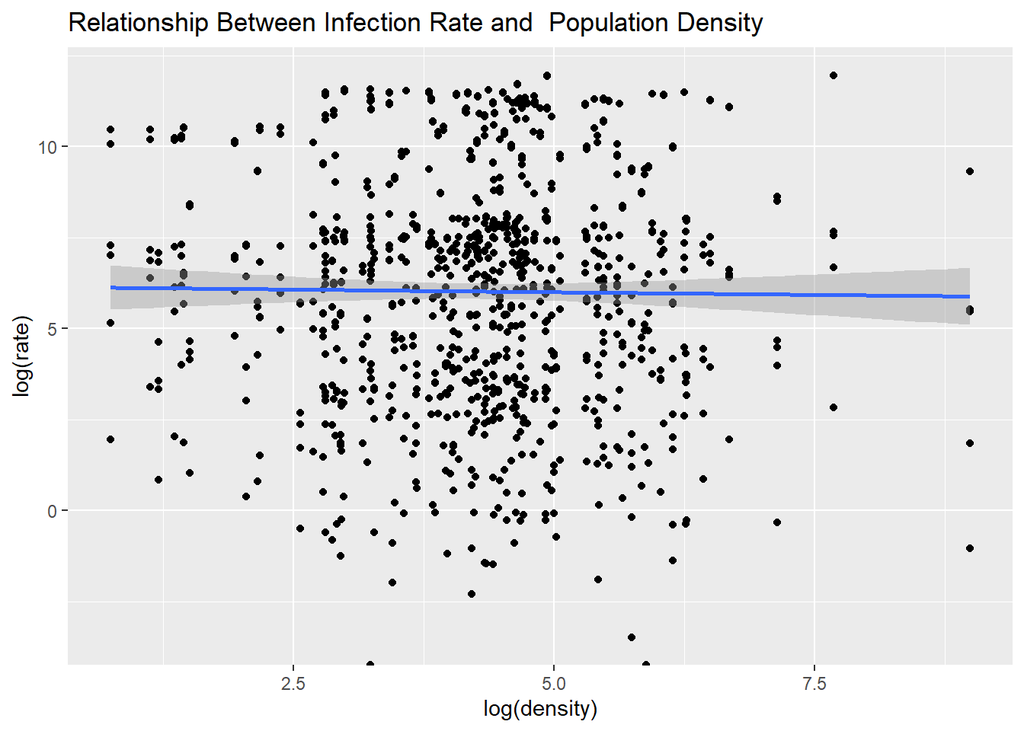

```r
d2 <- d%>%
filter(gdp_capita != is.na(gdp_capita))
library(ggplot2)
ggplot(d2, aes(x = log(density), y = log(rate))) +
geom_point() +
geom_smooth(method = "lm", formula = y ~ x) +
ggtitle("Relationship Between Infection Rate and  Population Density")
```

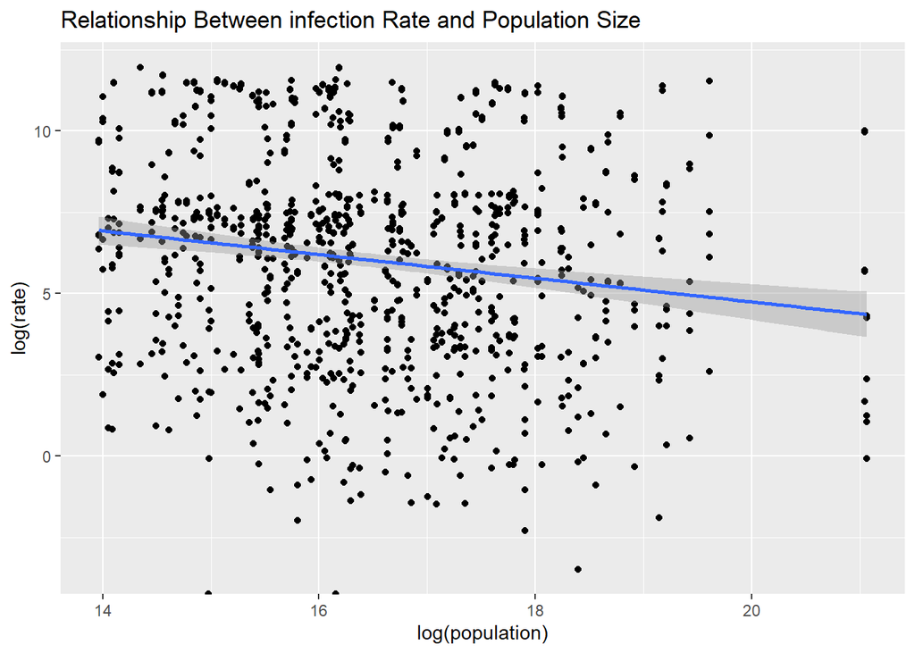

```r
#transform
library(ggplot2)
ggplot(d2, aes(x = log(population), y = log(rate))) +
geom_point() +
geom_smooth(method = "lm", formula = y ~ x) +
ggtitle("Relationship Between infection Rate and Population Size")
```

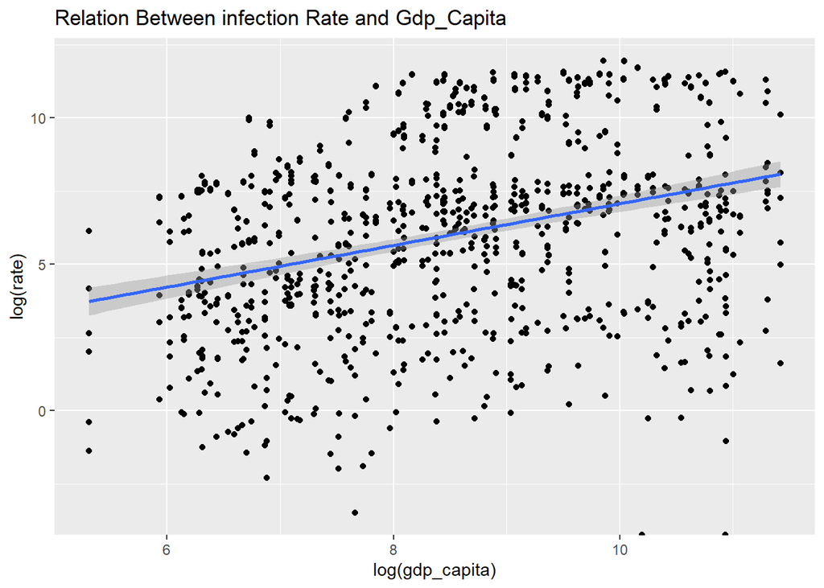

```r
#transform population
library(ggplot2)
ggplot(d2, aes(x = log(gdp_capita), y = log(rate))) +
geom_point() +
geom_smooth(method = "lm", formula = y ~ x) +
ggtitle("Relation Between infection Rate and Gdp_Capita")
```

```r
#transform GDP capita
d2 <- na.omit(d2)
model <- lm(log1p(rate) ~ log1p(density) + log1p(population) + log1p(gdp_capita) + income, data = d2)
summary(model)
```

```
##
## Call:
## lm(formula = log1p(rate) ~ log1p(density) + log1p(population) +
##     log1p(gdp_capita) + income, data = d2)
##
## Residuals:
##     Min      1Q  Median      3Q     Max
## -7.1676 -1.8399 -0.0889  2.4494  5.6489
##
## Coefficients:
##                           Estimate Std. Error t value Pr(>|t|)
## (Intercept)                9.61600    2.24218   4.289 1.99e-05 ***
## log1p(density)            -0.01180    0.07675  -0.154  0.87781
## log1p(population)         -0.23189    0.07106  -3.264  0.00114 **
## log1p(gdp_capita)          0.12217    0.20857   0.586  0.55818
## incomeLow income          -2.35517    0.88496  -2.661  0.00792 **
## incomeLower middle income -1.23795    0.64821  -1.910  0.05648 .
## incomeNot classified      -1.25740    1.20350  -1.045  0.29640
## incomeUpper middle income  0.17017    0.42103   0.404  0.68618
## ---
## Signif. codes:  0 '***' 0.001 '**' 0.01 '*' 0.05 '.' 0.1 ' ' 1
##
## Residual standard error: 2.862 on 904 degrees of freedom
## Multiple R-squared:  0.1443, Adjusted R-squared:  0.1377
## F-statistic: 21.78 on 7 and 904 DF,  p-value: < 2.2e-16
```

CHALLENGE 6: Run stepwise selection using AIC to evaluate whether the full model or a nested, simpler model is preferred. What is the best model (based on AIC) of the possible ones involving these 4 predictors? What are the “pseudo- R2” values associated with the full and “best” models?

HINT: Check out Module 22 on module selection using AIC with the {MASS} package and Module 24 on calculating “pseudo- R2” values with {MuMIn}.

Repeat this modeling process to evaluate what combination of explanatory variables best predicts maximum daily infection rate. Are the important predictors the same? What additional or different variables are included?

```r
# Stepwise regression model
library(MASS)
step.model <- stepAIC(model, direction = "both",
trace = FALSE)
step.model$anova
```

```
## Stepwise Model Path
## Analysis of Deviance Table
##
## Initial Model:
## log1p(rate) ~ log1p(density) + log1p(population) + log1p(gdp_capita) +
##     income
##
## Final Model:
## log1p(rate) ~ log1p(population) + income
##
##
##                  Step Df  Deviance Resid. Df Resid. Dev      AIC
## 1                                        904   7403.050 1925.735
## 2    - log1p(density)  1 0.1936733       905   7403.244 1923.759
## 3 - log1p(gdp_capita)  1 2.9617461       906   7406.205 1922.123
```

The simple model with population and income is the best model.

```r
model2 <- lm(log1p(rate) ~ log1p(population) + log1p(gdp_capita) + income, data = d2)
summary(model2)
```

```
##
## Call:
## lm(formula = log1p(rate) ~ log1p(population) + log1p(gdp_capita) +
##     income, data = d2)
##
## Residuals:
##    Min     1Q Median     3Q    Max
## -7.154 -1.841 -0.084  2.450  5.635
##
## Coefficients:
##                           Estimate Std. Error t value Pr(>|t|)
## (Intercept)                9.55625    2.20707   4.330 1.66e-05 ***
## log1p(population)         -0.23333    0.07039  -3.315 0.000954 ***
## log1p(gdp_capita)          0.12496    0.20767   0.602 0.547518
## incomeLow income          -2.33833    0.87768  -2.664 0.007854 **
## incomeLower middle income -1.22701    0.64395  -1.905 0.057039 .
## incomeNot classified      -1.24079    1.19800  -1.036 0.300609
## incomeUpper middle income  0.18083    0.41506   0.436 0.663177
## ---
## Signif. codes:  0 '***' 0.001 '**' 0.01 '*' 0.05 '.' 0.1 ' ' 1
##
## Residual standard error: 2.86 on 905 degrees of freedom
## Multiple R-squared:  0.1443, Adjusted R-squared:  0.1386
## F-statistic: 25.44 on 6 and 905 DF,  p-value: < 2.2e-16
```

CHALLENGE 7: To the best model you determined in CHALLENGE 6 for predicting the maximum daily infection rate, add in the maximum social distancing (max_sd) and maximum movement restriction (max_mr) score per country. Do either of these additional variables improve the model significantly?

HINT: Again, you should run exploratory visualizations to see whether or max_sd and max_mr should be transformed… they should be! You will want to consider using the log1p() rather than log() function to do your transformation as there are a couple of countries for which the value of max_sd is zero and log(0) is undefined. Alternatively, you could filter those two countries from your dataset.

[figure not shown]

```r
library(ggplot2)
ggplot(d2, aes(x = log1p(max_sd), y = log10(rate))) +
geom_point() +
geom_smooth(method = "lm", formula = y ~ x) +
ggtitle("Relation Between  Maximum Social distancing and  Gdp_Capita")
```

[figure not shown]

```r
library(ggplot2)
ggplot(d2, aes(x = log1p(max_mr), y = log10(rate))) +
geom_point() +
geom_smooth(method = "lm", formula = y ~ x) +
ggtitle("Relation Betwenn Maximum Movement Restriction and  Gdp_Capita")
```